# Homework 3

Samantha Rabinowitz, sar4357

5/3/2020

## Challenge 1

The code below loads the **KamilarAndCooperData** dataset and creates a linear model for the effect of mean species brain size (measured in grams) on longevity (measured in months), both before (fit1) and after (fit2) log transforming.

```r
f <- "https://raw.githubusercontent.com/difiore/ADA-datasets/master/KamilarAndCooperData.csv"
d <- read_csv(f, col_names = TRUE)
fit1 <- lm(MaxLongevity_m ~ Brain_Size_Species_Mean, data = d)
fit2 <- lm(log(MaxLongevity_m) ~ log(Brain_Size_Species_Mean), data = d)
```

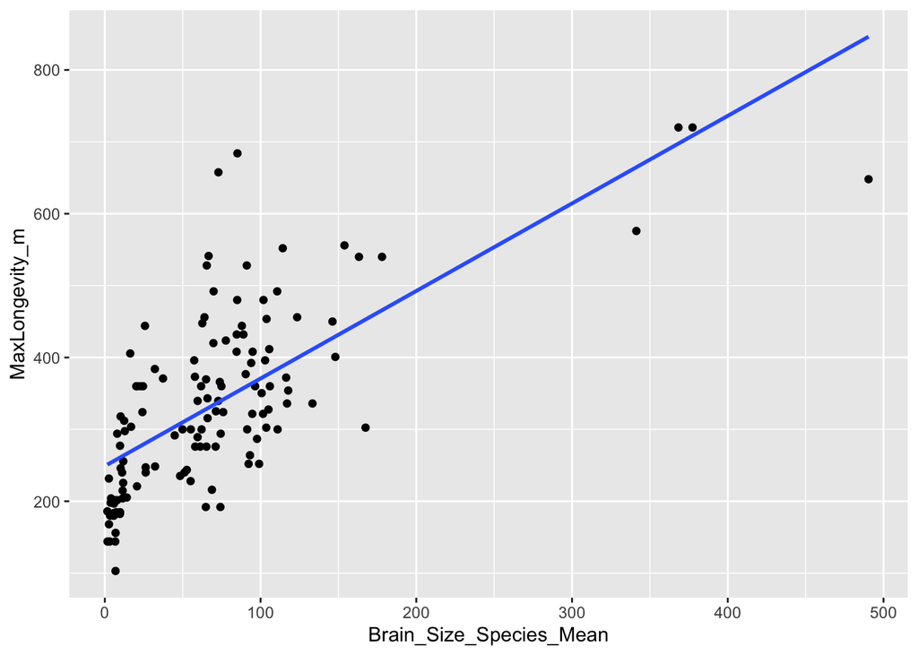

```r
(plot1 <- ggplot(d, aes(Brain_Size_Species_Mean, MaxLongevity_m)) +
  geom_point() +
  geom_smooth(method = "lm", se = FALSE))
```

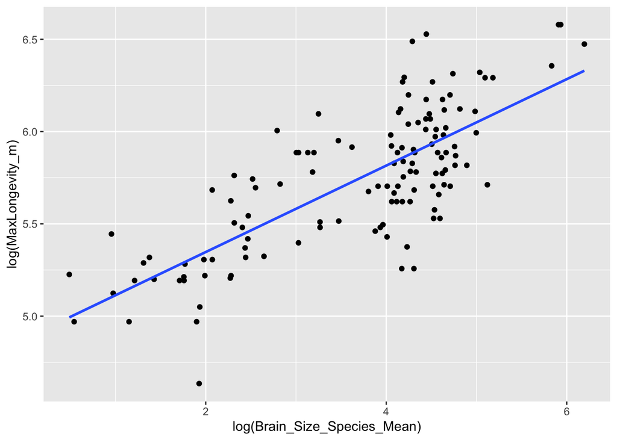

```r
(plot2 <- ggplot(d, aes(log(Brain_Size_Species_Mean), log(MaxLongevity_m))) +
  geom_point() +
  geom_smooth(method = "lm", se = FALSE))
```

The plots above demonstrate the relationship between longevity and species brain size, before and after log transforming the data. The line in blue on the plot has the slope and intercept generated from running a linear regression model for the effect of brain size on longevity.

```r
summary(fit1) #to show significance of the model
```

```
##
## Call:
## lm(formula = MaxLongevity_m ~ Brain_Size_Species_Mean, data = d)
##
## Residuals:
##     Min      1Q  Median      3Q     Max
## -198.27  -61.92  -17.78   56.16  331.36
##
## Coefficients:
##                         Estimate Std. Error t value Pr(>|t|)
## (Intercept)             248.9523    11.1111   22.41   <2e-16 ***
## Brain_Size_Species_Mean   1.2180     0.1101   11.06   <2e-16 ***
## ---
## Signif. codes:  0 '***' 0.001 '**' 0.01 '*' 0.05 '.' 0.1 ' ' 1
##
## Residual standard error: 90.91 on 126 degrees of freedom
##   (85 observations deleted due to missingness)
## Multiple R-squared:  0.4928, Adjusted R-squared:  0.4887
## F-statistic: 122.4 on 1 and 126 DF,  p-value: < 2.2e-16
```

```r
alpha <- 0.1
(CI_fit1 <- confint(fit1, level = 1 - alpha))
```

```
##                                5 %      95 %
## (Intercept)             230.540738 267.36379
## Brain_Size_Species_Mean   1.035571   1.40041
```

```r
summary(fit2) #to show significance of the model
```

```
##
## Call:
## lm(formula = log(MaxLongevity_m) ~ log(Brain_Size_Species_Mean),
##     data = d)
##
## Residuals:
##     Min      1Q  Median      3Q     Max
## -0.6955 -0.1750 -0.0097  0.1788  0.6084
##
## Coefficients:
##                              Estimate Std. Error t value Pr(>|t|)
## (Intercept)                   4.87895    0.06907   70.63   <2e-16 ***
## log(Brain_Size_Species_Mean)  0.23415    0.01781   13.15   <2e-16 ***
## ---
## Signif. codes:  0 '***' 0.001 '**' 0.01 '*' 0.05 '.' 0.1 ' ' 1
##
## Residual standard error: 0.2485 on 126 degrees of freedom
##   (85 observations deleted due to missingness)
## Multiple R-squared:  0.5784, Adjusted R-squared:  0.5751
## F-statistic: 172.9 on 1 and 126 DF,  p-value: < 2.2e-16
```

```r
(CI_fit2 <- confint(fit2, level = 1 - alpha))
```

```
##                                    5 %      95 %
## (Intercept)                  4.7644934 4.9934084
## log(Brain_Size_Species_Mean) 0.2046396 0.2636595
```

In *fit1*, the model produced before log transforming the data, the estimate of the slope is 1.2180. This can be interpreted to mean that for every additional gram that the brain size of a species increases, the longevity increases by a factor of 1.2180 months. As indicated in the summary above, this is a significant result. The 90% confidence interval around this slope is (1.03557, 1.40041).

In *fit2*, the model produced after log transforming the data, the estimate of the slope is 0.23415. This can be interpreted to mean that each time the brain size of a species increases by 1%, the longevity increases by 0.23415%. As indicated in the summary above, this is a significant result. The 90% confidence interval around this slope is (0.20464, 0.26366).

```r
df <- augment(fit1)
head(df)
```

```
## # A tibble: 6 x 10
##   .rownames MaxLongevity_m Brain_Size_Spec… .fitted .se.fit .resid    .hat
##   <chr>              <dbl>            <dbl>   <dbl>   <dbl>  <dbl>   <dbl>
## 1 1                   276              58.0    320.    8.14 -43.6  0.00801
## 2 4                   244.             52.6    313.    8.25 -69.5  0.00824
## 3 6                   300              49.9    310.    8.33  -9.71 0.00839
## 4 7                   240              51.1    311.    8.29 -71.2  0.00832
## 5 8                   300              55.2    316.    8.19 -16.2  0.00812
## 6 9                   360              20.7    274.    9.68  85.9  0.0113
## # … with 3 more variables: .sigma <dbl>, .cooksd <dbl>, .std.resid <dbl>
```

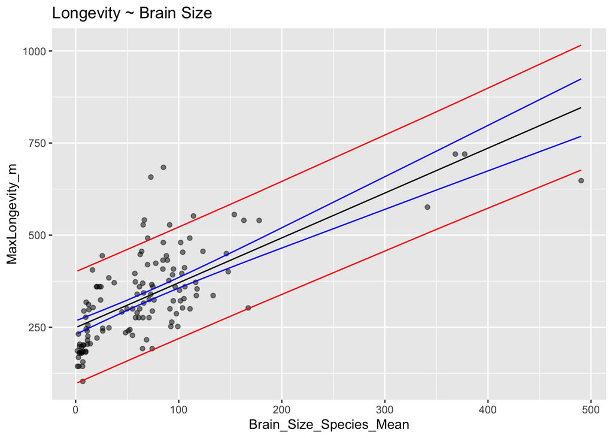

```r
sd <- glance(fit1) %>% pull(sigma)

df <- df %>%
  mutate(
    c.lwr = .fitted - qt(1 - alpha / 2, nrow(df) - 2) * .se.fit,
    c.upr = .fitted + qt(1 - alpha / 2, nrow(df) - 2) * .se.fit,
    se.prediction = sqrt(sd^2 + .se.fit^2),
    p.lwr = .fitted - qt(1 - alpha / 2, nrow(df) - 2) * se.prediction,
    p.upr = .fitted + qt(1 - alpha / 2, nrow(df) - 2) * se.prediction
  )

g <- ggplot(data = df, aes(x = Brain_Size_Species_Mean, y = MaxLongevity_m))
g <- g + geom_point(alpha = 0.5)
g <- g + geom_line(aes(x = Brain_Size_Species_Mean, y = .fitted), color = "black")
g <- g + geom_line(aes(x = Brain_Size_Species_Mean, y = c.lwr), color = "blue")
g <- g + geom_line(aes(x = Brain_Size_Species_Mean, y = c.upr), color = "blue")
g <- g + geom_line(aes(x = Brain_Size_Species_Mean, y = p.lwr), color = "red")
g <- g + geom_line(aes(x = Brain_Size_Species_Mean, y = p.upr), color = "red")
g + ggtitle("Longevity ~ Brain Size")
```

```r
df1 <- augment(fit2)
head(df1)
```

```
## # A tibble: 6 x 10
##   .rownames log.MaxLongevit… log.Brain_Size_… .fitted .se.fit  .resid    .hat
##   <chr>                <dbl>            <dbl>   <dbl>   <dbl>   <dbl>   <dbl>
## 1 1                     5.62             4.06    5.83  0.0230 -0.209  0.00857
## 2 4                     5.50             3.96    5.81  0.0225 -0.311  0.00823
## 3 6                     5.70             3.91    5.79  0.0223 -0.0906 0.00809
## 4 7                     5.48             3.93    5.80  0.0224 -0.320  0.00815
## 5 8                     5.70             4.01    5.82  0.0228 -0.114  0.00839
## 6 9                     5.89             3.03    5.59  0.0248  0.298  0.00997
## # … with 3 more variables: .sigma <dbl>, .cooksd <dbl>, .std.resid <dbl>
```

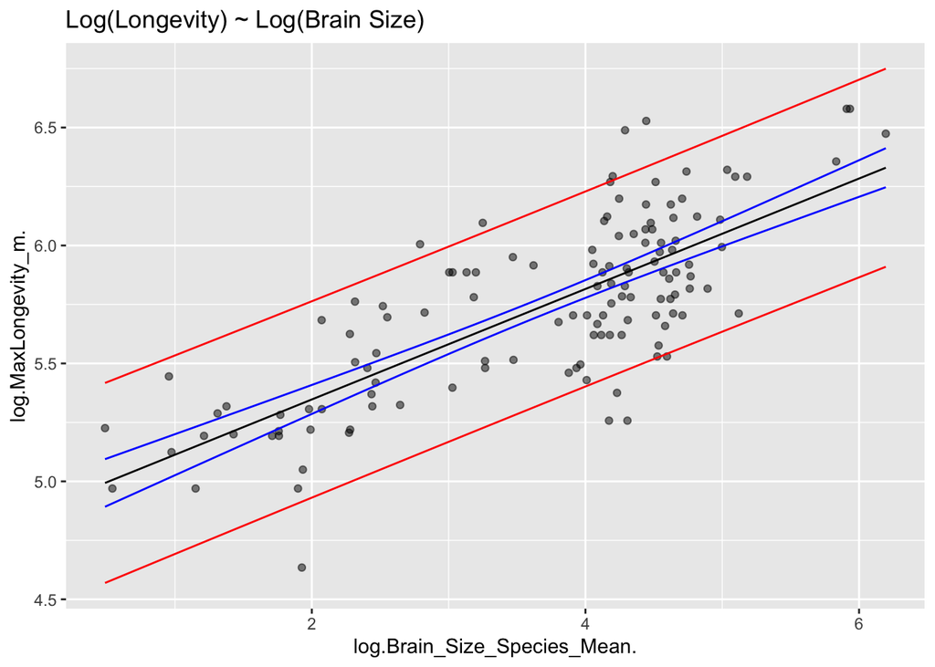

```r
sd <- glance(fit2) %>% pull(sigma)

df1 <- df1 %>%
  mutate(
    c.lwr = .fitted - qt(1 - alpha / 2, nrow(df1) - 2) * .se.fit,
    c.upr = .fitted + qt(1 - alpha / 2, nrow(df1) - 2) * .se.fit,
    se.prediction = sqrt(sd^2 + .se.fit^2),
    p.lwr = .fitted - qt(1 - alpha / 2, nrow(df1) - 2) * se.prediction,
    p.upr = .fitted + qt(1 - alpha / 2, nrow(df1) - 2) * se.prediction
  )

g <- ggplot(data = df1, aes(x = log.Brain_Size_Species_Mean., y = log.MaxLongevity_m.))
g <- g + geom_point(alpha = 0.5)
g <- g + geom_line(aes(x = log.Brain_Size_Species_Mean., y = .fitted), color = "black")
g <- g + geom_line(aes(x = log.Brain_Size_Species_Mean., y = c.lwr), color = "blue")
g <- g + geom_line(aes(x = log.Brain_Size_Species_Mean., y = c.upr), color = "blue")
g <- g + geom_line(aes(x = log.Brain_Size_Species_Mean., y = p.lwr), color = "red")
g <- g + geom_line(aes(x = log.Brain_Size_Species_Mean., y = p.upr), color = "red")
g + ggtitle("Log(Longevity) ~ Log(Brain Size)")
```

The above code adds lines for the 90% confidence (shown here in blue) and prediction (shown here in red) intervals to each plot.

```r
ci <- predict(fit1,
  newdata = data.frame(Brain_Size_Species_Mean = 750),
  interval = "confidence", level = 1 - alpha
)
ci
```

```
##        fit      lwr      upr
## 1 1162.445 1037.634 1287.256
```

```r
ci <- predict(fit2,
  newdata = data.frame(Brain_Size_Species_Mean = 750),
  interval = "confidence", level = 1 - alpha
)
ci
```

```
##        fit      lwr      upr
## 1 6.429038 6.334883 6.523194
```

As demonstrated most easily by the varying plots of the models shown above, the log-transformed data provides a more linear relationship to the data and therefore makes the model fit to the data more accurate (this can be seen visually by looking at the closer fit of the confidence intervals on the log transformed graph as compared to the graph before the transformation). From this model we can more accurately predict what the values for longevity will be given the brain size of a species so long as the brain size falls within the bounds of what the model can more accurately predict

## Challenge 2

The following code creates new variables for log transformed version of both *Body_mass_female_mean* and *HomeRange_km2* for later ease in use of the transformed variables. Then a linear regression is performed and the model is assigned to the name *fit3* and a summary of the output is displayed.

```r
d$log_Body_mass_female_mean <- log(d$Body_mass_female_mean)
d$log_HomeRange_km2 <- log(d$HomeRange_km2)

fit3 <- lm(log_HomeRange_km2 ~ log_Body_mass_female_mean, data = d)
summary(fit3)
```

```
##
## Call:
## lm(formula = log_HomeRange_km2 ~ log_Body_mass_female_mean, data = d)
##
## Residuals:
##     Min      1Q  Median      3Q     Max
## -3.3929 -0.9433 -0.0126  1.0944  3.6826
##
## Coefficients:
##                           Estimate Std. Error t value Pr(>|t|)
## (Intercept)               -9.44123    0.67293  -14.03   <2e-16 ***
## log_Body_mass_female_mean  1.03643    0.08488   12.21   <2e-16 ***
## ---
## Signif. codes:  0 '***' 0.001 '**' 0.01 '*' 0.05 '.' 0.1 ' ' 1
##
## Residual standard error: 1.423 on 135 degrees of freedom
##   (76 observations deleted due to missingness)
## Multiple R-squared:  0.5248, Adjusted R-squared:  0.5213
## F-statistic: 149.1 on 1 and 135 DF,  p-value: < 2.2e-16
```

The code below creates a bootstrapped sampling distribution for each coefficient. boot_dat generates a random sample with replacement from the dataset. fit generates the linear regression model of interest using the log transformed version of the varirables as assigned above. coef(fit) pulls the coefficient estimates generated from the model run for each random sample. replicate(1000,…) runs the provided functions 1000 times and saves them to the defined, samp_distn.

```r
set.seed(42)
samp_distn<-replicate(1000, {
  boot_dat <- sample_frac(d, replace=T)
  fit <- lm(log(HomeRange_km2) ~ log(Body_mass_female_mean), data=boot_dat)
  coef(fit)
})
```

The code below creates histograms of the sampling distributions created for each of the coefficients as defined by their titles.

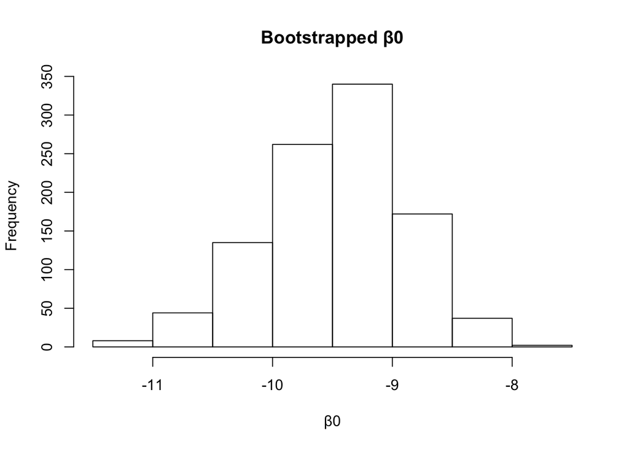

```r
hist(samp_distn[1,], main = "Bootstrapped β0", xlab = "β0")
```

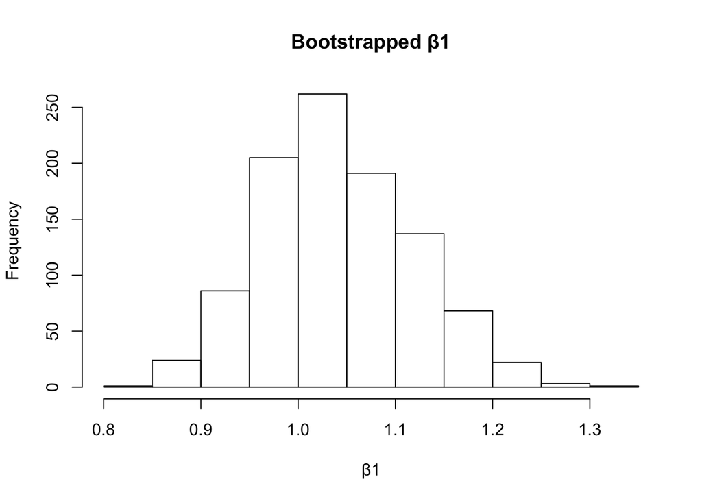

```r
hist(samp_distn[2,], main = "Bootstrapped β1", xlab = "β1")
```

The following code generates the 95% confidence intervals for each of the coefficients. This is accomplished by obtaining the standard error estimates for each coefficient by calculating the standard deviation of the previously generated sampling distributions. The quantile function is then used to determine the upper and lower bounds of the confidence intervals. The first interval listed is for β0 (the intercept) and the second is for β1 (the slope).

```r
sd(samp_distn[1,]) #intercept
```

```
## [1] 0.5996622
```

```r
sd(samp_distn[2,]) #slope
```

```
## [1] 0.07775093
```

```r
samp_distn <- samp_distn %>% as.data.frame()

alpha <- 0.05

p_lower <- alpha / 2
p_upper <- 1 - (alpha / 2)

quantile(samp_distn[1,], p_lower); quantile(samp_distn[1,], p_upper) #intercept
```

```
##                  2.5%
## (Intercept) -10.73197
```

```
##                 97.5%
## (Intercept) -8.415115
```

```r
quantile(samp_distn[2,], p_lower); quantile(samp_distn[2,], p_upper) #slope
```

```
##                                 2.5%
## log(Body_mass_female_mean) 0.9011129
```

```
##                               97.5%
## log(Body_mass_female_mean) 1.202456
```

```r
tidy(fit3)
```

```
## # A tibble: 2 x 5
##   term                      estimate std.error statistic  p.value
##   <chr>                        <dbl>     <dbl>     <dbl>    <dbl>
## 1 (Intercept)                  -9.44    0.673      -14.0 3.82e-28
## 2 log_Body_mass_female_mean     1.04    0.0849      12.2 1.45e-23
```

```r
confint(fit3, level = 1 - alpha)
```

```
##                                 2.5 %    97.5 %
## (Intercept)               -10.7720889 -8.110374
## log_Body_mass_female_mean   0.8685707  1.204292
```

## Challenge 3

```r
boot_lm <- function(d, model, conf.level=0.95, reps = 1000){
  fit <- lm(model, d)

  coef = summary(fit)$coefficients[,1]

  se = summary(fit)$coefficients[,2]

  conf = confint(fit, level = conf.level)

  samp_dist<-replicate(reps, {
    boot_dat <- sample_frac(d, replace=T)
    mod <- lm(model, data=boot_dat)
    coef(mod)
    })

  boot_beta0 <- mean(samp_dist[1,])
  boot_beta1 <- mean(samp_dist[2,])
  boot_coef = rbind(boot_beta0,boot_beta1)

  se_inter <- sd(samp_dist[1,])
  se_slope <- sd(samp_dist[2,])
  boot_se = rbind(se_inter,se_slope)

  alpha <- 1 - conf.level
  p_lower <- alpha / 2
  p_upper <- 1 - (alpha / 2)

  intercept_lower <- quantile(samp_dist[1,], p_lower)
  intercept_upper <- quantile(samp_dist[1,], p_upper)

  slope_lower <- quantile(samp_dist[2,], p_lower)
  slope_upper <- quantile(samp_dist[2,], p_upper)

  CI_boot_lower = rbind(intercept_lower,slope_lower)
  CI_boot_upper = rbind(intercept_upper,slope_upper)

  data.frame(coef, se, conf, boot_coef, boot_se, CI_boot_lower, CI_boot_upper)

}

boot_lm(d, "log(DayLength_km) ~ log(Body_mass_female_mean)")
```

```
##                                  coef        se      X2.5..   X97.5..
## (Intercept)                -0.1427624 0.4650068 -1.06510122 0.7795764
## log(Body_mass_female_mean)  0.0389422 0.0566739 -0.07347022 0.1513546
##                              boot_coef    boot_se       X2.5.    X97.5.
## (Intercept)                -0.12449543 0.46592298 -1.06224998 0.7533547
## log(Body_mass_female_mean)  0.03612925 0.05928822 -0.07686141 0.1571563
```

```r
boot_lm(d, "log(HomeRange_km2) ~ log(Body_mass_female_mean)")
```

```
##                                 coef         se      X2.5..   X97.5.. boot_coef
## (Intercept)                -9.441231 0.67293459 -10.7720889 -8.110374 -9.450080
## log(Body_mass_female_mean)  1.036432 0.08487709   0.8685707  1.204292  1.037343
##                               boot_se       X2.5.    X97.5.
## (Intercept)                0.59292617 -10.6685598 -8.388780
## log(Body_mass_female_mean) 0.07668745   0.8951052  1.193527
```

In the resulting dataframes above, the first half of the dataset provides the calculations using the information generated from the lm() function. The second half uses information generated from the bootstrapped sampling distributions created using the variables of interest.